# JayavantiWesley_9019852_A1_Frameworks

**Goal of Linear Regression for this Project**

The goal of using linear regression is to predict median_house_value (house price) based on features like:

1. Location (longitude, latitude)
2. Housing characteristics (median age, total rooms, total bedrooms, population, households)
3. Economic factors (median_income)
4. Proximity to the ocean (categorical column: ocean_proximity)

Linear regression helps us understand the relationship between these variables and housing prices, and identify which factor has the strongest impact

```python
import pandas as pd

# Loading the dataset using read_csv()
file_path = "housing.csv"
df = pd.read_csv(file_path)

# Displaying the first few rows to understand the structure of the dataset
df.head()
```

|  | longitude | latitude | housing_median_age | total_rooms | total_bedrooms | population | households | median_income | median_house_value | ocean_proximity |
| --- | --- | --- | --- | --- | --- | --- | --- | --- | --- | --- |
| 0 | -122.23 | 37.88 | 41.0 | 880.0 | 129.0 | 322.0 | 126.0 | 8.3252 | 452600.0 | NEAR BAY |
| 1 | -122.22 | 37.86 | 21.0 | 7099.0 | 1106.0 | 2401.0 | 1138.0 | 8.3014 | 358500.0 | NEAR BAY |
| 2 | -122.24 | 37.85 | 52.0 | 1467.0 | 190.0 | 496.0 | 177.0 | 7.2574 | 352100.0 | NEAR BAY |
| 3 | -122.25 | 37.85 | 52.0 | 1274.0 | 235.0 | 558.0 | 219.0 | 5.6431 | 341300.0 | NEAR BAY |
| 4 | -122.25 | 37.85 | 52.0 | 1627.0 | 280.0 | 565.0 | 259.0 | 3.8462 | 342200.0 | NEAR BAY |

```python
# Displaying summary statistics using describe()

print(df.describe())
```

```
          longitude      latitude  housing_median_age   total_rooms  \
count  20640.000000  20640.000000        20640.000000  20640.000000
mean    -119.569704     35.631861           28.639486   2635.763081
std        2.003532      2.135952           12.585558   2181.615252
min     -124.350000     32.540000            1.000000      2.000000
25%     -121.800000     33.930000           18.000000   1447.750000
50%     -118.490000     34.260000           29.000000   2127.000000
75%     -118.010000     37.710000           37.000000   3148.000000
max     -114.310000     41.950000           52.000000  39320.000000

       total_bedrooms    population    households  median_income  \
count    20433.000000  20640.000000  20640.000000   20640.000000
mean       537.870553   1425.476744    499.539680       3.870671
std        421.385070   1132.462122    382.329753       1.899822
min          1.000000      3.000000      1.000000       0.499900
25%        296.000000    787.000000    280.000000       2.563400
50%        435.000000   1166.000000    409.000000       3.534800
75%        647.000000   1725.000000    605.000000       4.743250
max       6445.000000  35682.000000   6082.000000      15.000100

       median_house_value
count        20640.000000
mean        206855.816909
std         115395.615874
min          14999.000000
25%         119600.000000
50%         179700.000000
75%         264725.000000
max         500001.000000
```

```python
# Check for missing values
missing_values = df.isnull().sum()
missing_values
```

```
longitude               0
latitude                0
housing_median_age      0
total_rooms             0
total_bedrooms        207
population              0
households              0
median_income           0
median_house_value      0
ocean_proximity         0
dtype: int64
```

```python
# Generate summary statistics for the four variables
summary_stats = df[["median_house_value", "median_income", "population", "households"]].describe()
summary_stats
```

|  | median_house_value | median_income | population | households |
| --- | --- | --- | --- | --- |
| count | 20640.000000 | 20640.000000 | 20640.000000 | 20640.000000 |
| mean | 206855.816909 | 3.870671 | 1425.476744 | 499.539680 |
| std | 115395.615874 | 1.899822 | 1132.462122 | 382.329753 |
| min | 14999.000000 | 0.499900 | 3.000000 | 1.000000 |
| 25% | 119600.000000 | 2.563400 | 787.000000 | 280.000000 |
| 50% | 179700.000000 | 3.534800 | 1166.000000 | 409.000000 |
| 75% | 264725.000000 | 4.743250 | 1725.000000 | 605.000000 |
| max | 500001.000000 | 15.000100 | 35682.000000 | 6082.000000 |

1.median_house_value (y or the Dependent Variable): Meaning: It is the median house price for a given area Range: Approximately $14,999 to $500,001 (possibility of upper cap) Insight: Some house prices are clustered at the maximum value, suggesting data truncation or a price ceiling

2.median_income (X or the Independent Variable) Meaning: It is the median household income in the area (scaled,probably in 1000s) Range: 0 to ~15 (interpreted as $0 to ~$150,000 annual income) Insight: Strong positive correlation with house values, making it a key predictor

4.households (X ,Independent Variable) Meaning: It is the number of occupied housing units in a area Range: 1 to ~6,000 households(possible scaling applied) Insight: Less positive trend with house values, but overall weak predictor

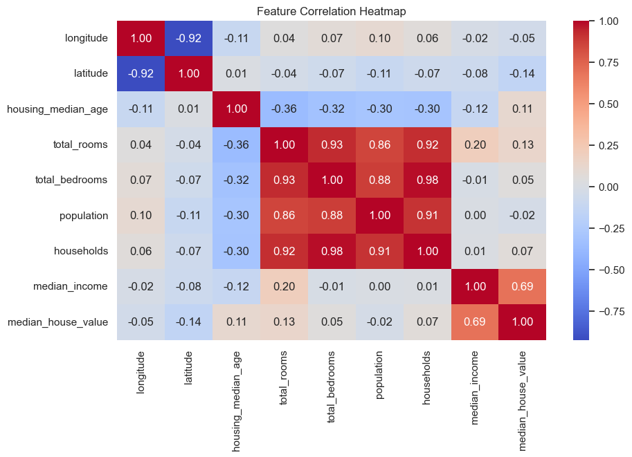

```python
# Correlation Heatmap

import matplotlib.pyplot as plt
import seaborn as sns
import numpy as np

# develop the Correlation matrix
correlation_matrix = df.corr(numeric_only=True)

# Visualization of correlation heatmap
plt.figure(figsize=(10, 6))
sns.heatmap(correlation_matrix, annot=True, cmap="coolwarm", fmt=".2f")
plt.title("Feature Correlation Heatmap")
plt.show()
```

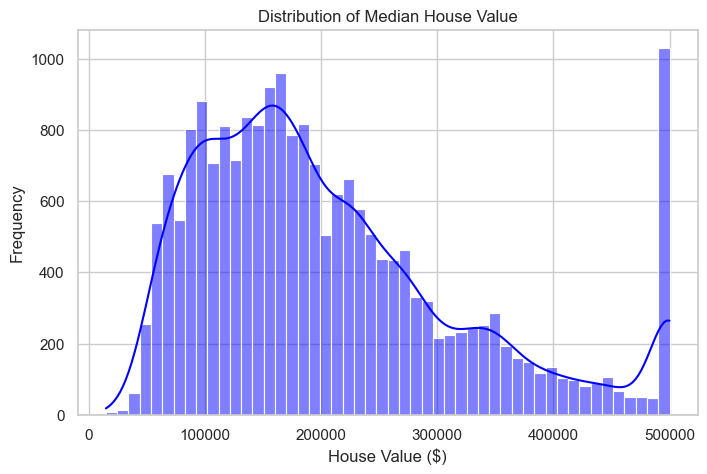

```
(       median_house_value  median_income    population    households
 count        20640.000000   20640.000000  20640.000000  20640.000000
 mean        206855.816909       3.870671   1425.476744    499.539680
 std         115395.615874       1.899822   1132.462122    382.329753
 min          14999.000000       0.499900      3.000000      1.000000
 25%         119600.000000       2.563400    787.000000    280.000000
 50%         179700.000000       3.534800   1166.000000    409.000000
 75%         264725.000000       4.743250   1725.000000    605.000000
 max         500001.000000      15.000100  35682.000000   6082.000000,
 longitude               0
 latitude                0
 housing_median_age      0
 total_rooms             0
 total_bedrooms        207
 population              0
 households              0
 median_income           0
 median_house_value      0
 ocean_proximity         0
 dtype: int64)
```

```python
# Histplot with KDE (kernel density estimate-epresents the data using a continuous probability density curve)
# Distribution of the target variable (median_house_value)

plt.figure(figsize=(8, 5))
sns.histplot(df["median_house_value"], bins=50, kde=True, color="blue")
plt.title("Distribution of Median House Value")
plt.xlabel("House Value ($)")
plt.ylabel("Frequency")
plt.show()

summary_stats, missing_values
```

**Summary of EDA:**

Missing Values:

total_bedrooms has 207 missing values. We can fix this using median or mean

**Correlations:**

median_income has the highest correlation with median_house_value (~0.69), suggesting it is a strong predicting factor total_rooms and total_bedrooms are highly correlated, so we can consider creating new features like rooms per household.

**Distribution of Target Variable:**

median_house_value has a long right tail, so we can use log transformation to normalize the data. The maximum house value is 500,001, suggesting a possible cap on house prices

```python
# Function to run regression and produce regression summary results
import statsmodels.api as sm # type: ignore

def run_regres(dependent_var, independent_var):
    X = sm.add_constant(df[independent_var])  # Add intercept
    y = df[dependent_var]
    model = sm.OLS(y, X).fit()
    return model.summary()

# Run the three regressions
print(run_regres("median_house_value", "median_income"))
print(run_regres("median_house_value", "population"))
print(run_regres("median_house_value", "households"))
```

```
                            OLS Regression Results
==============================================================================
Dep. Variable:     median_house_value   R-squared:                       0.473
Model:                            OLS   Adj. R-squared:                  0.473
Method:                 Least Squares   F-statistic:                 1.856e+04
Date:                Fri, 31 Jan 2025   Prob (F-statistic):               0.00
Time:                        16:03:23   Log-Likelihood:            -2.6325e+05
No. Observations:               20640   AIC:                         5.265e+05
Df Residuals:                   20638   BIC:                         5.265e+05
Df Model:                           1
Covariance Type:            nonrobust
=================================================================================
                    coef    std err          t      P>|t|      [0.025      0.975]
---------------------------------------------------------------------------------
const          4.509e+04   1322.872     34.082      0.000    4.25e+04    4.77e+04
median_income  4.179e+04    306.806    136.223      0.000    4.12e+04    4.24e+04
==============================================================================
Omnibus:                     4245.795   Durbin-Watson:                   0.655
Prob(Omnibus):                  0.000   Jarque-Bera (JB):             9273.446
Skew:                           1.191   Prob(JB):                         0.00
Kurtosis:                       5.260   Cond. No.                         10.2
==============================================================================

Notes:
[1] Standard Errors assume that the covariance matrix of the errors is correctly specified.
                            OLS Regression Results
==============================================================================
Dep. Variable:     median_house_value   R-squared:                       0.001
Model:                            OLS   Adj. R-squared:                  0.001
Method:                 Least Squares   F-statistic:                     12.55
Date:                Fri, 31 Jan 2025   Prob (F-statistic):           0.000398
Time:                        16:03:23   Log-Likelihood:            -2.6986e+05
No. Observations:               20640   AIC:                         5.397e+05
Df Residuals:                   20638   BIC:                         5.397e+05
Df Model:                           1
Covariance Type:            nonrobust
==============================================================================
                 coef    std err          t      P>|t|      [0.025      0.975]
------------------------------------------------------------------------------
const       2.104e+05   1290.927    163.012      0.000    2.08e+05    2.13e+05
```

[output cut: 24 more lines]

```
                 coef    std err          t      P>|t|      [0.025      0.975]
------------------------------------------------------------------------------
const       1.969e+05   1318.748    149.330      0.000    1.94e+05       2e+05
households    19.8728      2.096      9.479      0.000      15.764      23.982
==============================================================================
Omnibus:                     2520.280   Durbin-Watson:                   0.322
Prob(Omnibus):                  0.000   Jarque-Bera (JB):             3541.913
Skew:                           0.998   Prob(JB):                         0.00
Kurtosis:                       3.370   Cond. No.                     1.04e+03
==============================================================================

Notes:
[1] Standard Errors assume that the covariance matrix of the errors is correctly specified.
[2] The condition number is large, 1.04e+03. This might indicate that there are
strong multicollinearity or other numerical problems.
```

**Results of Regresssion:**

*1) Median Income vs. Median House Value*

Coefficient= 41,790 (positive and highly significant) R-squared= 0.473 (implies 47.3% variation in house values) Conclusion: Higher median income has strong association with higher house values

*2) Population vs. Median House Value*

Coefficient: -2.51 (negative and statistically significant) R-squared: 0.001 (explains only 0.1% of the variation) Conclusion: Population size is very weakly negative in association with house values

*3)Number of Households vs. Median House Value*

Coefficient= 19.87 (positive and statistically significant) R-squared= 0.004 (explains only 0.4% of the variation) Conclusion: More households are associated with high house values, but the effect is weak

*Final Conclusion:*

Median income is hence the strongest predictor of house values Population and number of households have minimal deterministic power over house value

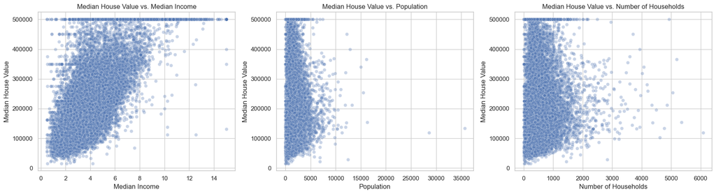

```python
# Scatter plots

import seaborn as sns
import matplotlib.pyplot as plt

# Set plot style
sns.set_theme(style="whitegrid")

# Create figure and axes
fig, axes = plt.subplots(1, 3, figsize=(18, 5))

# Scatter plot for Median Income vs. Median House Value
sns.scatterplot(x=df["median_income"], y=df["median_house_value"], alpha=0.3, ax=axes[0])
axes[0].set_title("Median House Value vs. Median Income")
axes[0].set_xlabel("Median Income")
axes[0].set_ylabel("Median House Value")

# Scatter plot for Population vs. Median House Value
sns.scatterplot(x=df["population"], y=df["median_house_value"], alpha=0.3, ax=axes[1])
axes[1].set_title("Median House Value vs. Population")
axes[1].set_xlabel("Population")
axes[1].set_ylabel("Median House Value")

# Scatter plot for Households vs. Median House Value
sns.scatterplot(x=df["households"], y=df["median_house_value"], alpha=0.3, ax=axes[2])
axes[2].set_title("Median House Value vs. Number of Households")
axes[2].set_xlabel("Number of Households")
axes[2].set_ylabel("Median House Value")

# Show plots
plt.tight_layout()
plt.show()
```

**Interpretting the Scatter Plots:**

1.Median House Value vs. Median Income The scatter plot shows a strong positive relationship between median income and median house value As income increases, house value tends to increase significantly the clustering effect at the high end is seen , so its a possible cap on house values in the dataset This aligns with the high R-squared value (0.473) from regression analysis, indicating that income is a key predictor of house prices

2.Median House Value vs. Population No clear trend can be observed; points are scattered So population size has little or no direct impact on median house value The regression result (R-squared = 0.001) confirms that population is not a meaningful predictor of house prices

3.Median House Value vs. Number of Households A slight positive trend is observed, but it's weak and noisy Similar to population, the number of households does not appear to be a strong determinant of house values This is supported by the regression results (R-squared = 0.004), showing that households explain very little variance in house prices

More Insights: median income has the strongest linear relationship with house values, so it should be included in future models Population and households have less effect, so they may not be useful independent variables in a predictive model multiple regression (including more relevant variables) might help to improve predictions

```python
# fit multiple models, perform cross-validation, and select the best one

from sklearn.model_selection import train_test_split
from sklearn.preprocessing import StandardScaler, OneHotEncoder
from sklearn.impute import SimpleImputer
from sklearn.pipeline import Pipeline
from sklearn.compose import ColumnTransformer

# Handle missing values by imputing median
df["total_bedrooms"].fillna(df["total_bedrooms"].median(), inplace=True)

# Feature Engineering: Create new features
df["rooms_per_household"] = df["total_rooms"] / df["households"]
df["bedrooms_per_room"] = df["total_bedrooms"] / df["total_rooms"]
df["population_per_household"] = df["population"] / df["households"]

# Define numerical and categorical features
num_features = ["longitude", "latitude", "housing_median_age", "total_rooms", "total_bedrooms",
                "population", "households", "median_income", "rooms_per_household",
                "bedrooms_per_room", "population_per_household"]
cat_features = ["ocean_proximity"]

# Preprocessing pipeline
num_pipeline = Pipeline([("scaler", StandardScaler())])
cat_pipeline = Pipeline([("encoder", OneHotEncoder(handle_unknown="ignore"))])

preprocessor = ColumnTransformer([
    ("num", num_pipeline, num_features),
    ("cat", cat_pipeline, cat_features)
])

# Split data
X = df.drop(columns=["median_house_value"])
y = df["median_house_value"]
X_train, X_test, y_train, y_test = train_test_split(X, y, test_size=0.2, random_state=42)

X_train.shape, X_test.shape
```

```
((16512, 12), (4128, 12))
```

```python
from sklearn.linear_model import LinearRegression, Ridge, Lasso
from sklearn.ensemble import RandomForestRegressor
from sklearn.svm import SVR
from sklearn.model_selection import cross_val_score
from sklearn.pipeline import Pipeline

# Define models
models = {
    "Linear Regression": LinearRegression(),
    "Ridge Regression": Ridge(alpha=1.0),
    "Lasso Regression": Lasso(alpha=0.01),
    "Random Forest": RandomForestRegressor(n_estimators=100, random_state=42),
    "Support Vector Regression": SVR(kernel="rbf")
}

# Function to evaluate models using cross-validation
def evaluate_models(models, X_train, y_train):
    results = {}
    for name, model in models.items():
        pipeline = Pipeline([("preprocessor", preprocessor), ("model", model)])
        scores = cross_val_score(pipeline, X_train, y_train, cv=5, scoring="neg_mean_absolute_error")
        results[name] = -scores.mean()  # Convert negative MAE to positive
    return results

# Evaluate models
model_performance = evaluate_models(models, X_train, y_train)

# Print results
for model, mae in model_performance.items():
    print(f"{model}: MAE = {mae:.2f}")
```

```
Linear Regression: MAE = 48871.94
Ridge Regression: MAE = 48872.03
Lasso Regression: MAE = 48871.94
Random Forest: MAE = 32913.94
Support Vector Regression: MAE = 88320.52
```

```python
import warnings
warnings.filterwarnings("ignore")
```

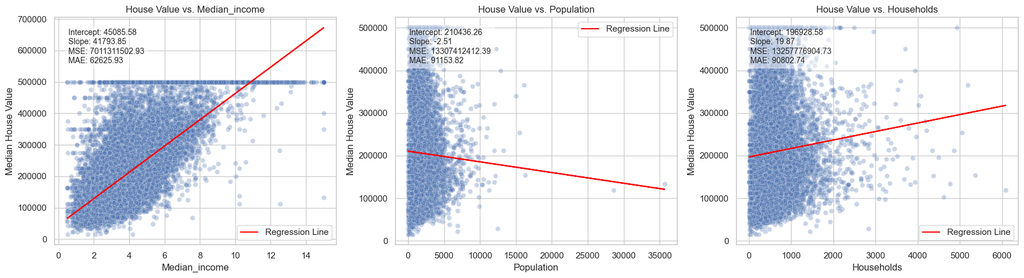

```python
# Function to run regression and return model parameters
from sklearn.metrics import mean_absolute_error, mean_squared_error


def plot_regression(dependent_var, independent_var, ax):
    X = sm.add_constant(df[independent_var])  # Add intercept
    y = df[dependent_var]
    model = sm.OLS(y, X).fit()

    # Predictions
    y_pred = model.predict(X)

    # Extracting intercept and slope
    intercept = model.params[0]
    slope = model.params[1]

    # Error metrics
    mse = mean_squared_error(y, y_pred)
    mae = mean_absolute_error(y, y_pred)

    # Scatter plot
    sns.scatterplot(x=df[independent_var], y=y, alpha=0.3, ax=ax)

    # Regression line
    ax.plot(df[independent_var], y_pred, color='red', label="Regression Line")

    # Title and labels
    ax.set_title(f"House Value vs. {independent_var.capitalize()}")
    ax.set_xlabel(independent_var.capitalize())
    ax.set_ylabel("Median House Value")

    # Text box with model details
    textstr = f"Intercept: {intercept:.2f}\nSlope: {slope:.2f}\nMSE: {mse:.2f}\nMAE: {mae:.2f}"
    ax.text(0.05, 0.95, textstr, transform=ax.transAxes, fontsize=10,
            verticalalignment='top', bbox=dict(facecolor='white', alpha=0.5))

    ax.legend()

# Create subplots
fig, axes = plt.subplots(1, 3, figsize=(18, 5))

# Plot regressions
plot_regression("median_house_value", "median_income", axes[0])
plot_regression("median_house_value", "population", axes[1])
plot_regression("median_house_value", "households", axes[2])

# Show plots
plt.tight_layout()
plt.show()
```

**Conclusion: Comparing Regression Models**

*1. House Value vs Median Income*

This model had the strongest relationship, with the highest R-squared value (~0.47), so it explains about 47% of the variation in house prices. The scatter plot shows a clear upward trend, indicating a strong positive correlation. The Mean Squared Error (MSE) and Mean Absolute Error (MAE) were relatively low, meaning this model makes better predictions than the others. Key Insight: Median income is a crucial predictor of housing prices, likely because higher-income areas have more demand for expensive housing.

*2. House Value vs Population*

This model had almost no explanatory power (R-squared ~0.001), meaning population size has no meaningful impact on house values. The scatter plot showed a random distribution of points, reinforcing that population does not drive house prices. Key Insight: Population size alone does not determine house values, as density, location, and economic factors play a more significant role.

*3. House Value vs Number of Households*

This model had slightly better but still weak explanatory power (R-squared ~0.004), showing a small positive relationship. The regression line showed a minor upward trend, but the overall spread of data points remained high. Key Insight: The number of households correlates slightly with house values, but not as strongly as income. Larger household counts may suggest larger communities but do not directly determine property values.

*Conclusion:*

Median income is the only meaningful predictor of house value among the three variables analyzed Population and the number of households alone are poor predictors The next step would be to run a multiple regression model, with additional variables (like housing density, proximity to amenities, etc to improve accuracy f the predictions.